# ENV221 L06

Author

Peng Zhao

# 1 Overview of the module and R

# 2 R Basic Operations

# 3 R Programming

# 4 Statistical Graphs

# 5 Basic Concepts

# 6 Descriptive statistics

## 6.1 Learning objectives

In this lecture, you will

1. know how to describe categorical data and numerical data, and
2. use appropriate tables and graphs for presenting categorical and numerical data.

## 6.2 Categorical data

Categorical data are often described with frequency/count and proportion.

### 6.2.1 One-way tables

```r
x <- read.csv('data/students_env221.csv')
tb_gender <- table(x$GENDER)
tb_gender
```

```
Female   Male
    35     22
```

```r
prop.table(tb_gender)
```

```
   Female      Male
0.6140351 0.3859649
```

```r
# marginal statistics
Epi::stat.table(list(GENDER), data = x, margins = TRUE)
```

```
 -----------------
 GENDER   count()
 -----------------
 Female        35
 Male          22

 Total         57
 -----------------
```

which could be displayed as a long version:

```r
dtf_gender <- data.frame(tb_gender)
names(dtf_gender) <- c('Gender', 'Frequency')
```

| Gender | Frequency |
| --- | --- |
| Female | 35 |
| Male | 22 |

Visualization: bar plots and pie charts

```r
# Bar plot is a common way
library(ggplot2)
ggplot(x) +
  geom_bar(aes(y = GENDER, fill = GENDER))

# A pie chart is good if you have only a few groups.
pie(tb_gender)

# but is a disaster when you have many groups
tb_disp <- table(mtcars$disp)
pie(tb_disp, col = rainbow(length(tb_disp)))
# especially a 3-D pie chart.
library(plotrix)
pie3D(tb_disp)
# instead, use a bar plot
```

[output not shown]

### 6.2.2 Two-way tables

Contingency tables/cross-tabulation

```r
table(x$GENDER, x$HOME)
```

```
          North China North China Other places South China
  Female            1          11            1          22
  Male              0           8            2          12
```

```r
unique(x$HOME)
```

```
[1] "South China"  "North China"  "Other places" " North China"
```

```r
x$HOME[x$HOME == ' North China'] <- 'North China'
table(x$GENDER, x$HOME)
```

```
         North China Other places South China
  Female          12            1          22
  Male             8            2          12
```

```r
tb2 <- table(x$GENDER, x$HOME)
prop.table(tb2)
```

```
         North China Other places South China
  Female  0.21052632   0.01754386  0.38596491
  Male    0.14035088   0.03508772  0.21052632
```

```r
round(prop.table(tb2), 3)
```

```
         North China Other places South China
  Female       0.211        0.018       0.386
  Male         0.140        0.035       0.211
```

```r
Epi::stat.table(list(GENDER, HOME), data = x, margins = TRUE)
```

```
 -----------------------------------------
         --------------HOME---------------
 GENDER     North   Other   South   Total
            China  places   China
 -----------------------------------------
 Female        12       1      22      35
 Male           8       2      12      22

 Total         20       3      34      57
 -----------------------------------------
```

Question: How do you display it in a long version?

```r
dtf2 <- data.frame(table(x$GENDER, x$HOME))
names(dtf2) <- c('Gender', 'Home', 'Frequency')
```

| Gender | Home | Frequency |
| --- | --- | --- |
| Female | North China | 12 |
| Male | North China | 8 |
| Female | Other places | 1 |
| Male | Other places | 2 |
| Female | South China | 22 |
| Male | South China | 12 |

Visualization: bar plots

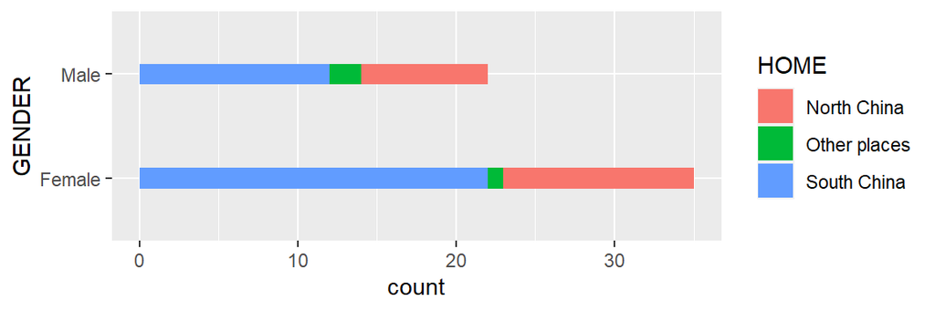

```r
library(ggplot2)
ggplot(x) + geom_bar(aes(y = GENDER, fill = HOME), width = 0.2)
```

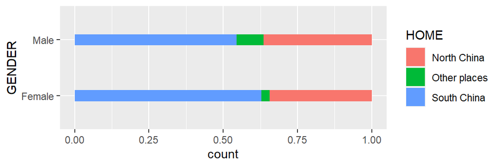

```r
ggplot(x) + geom_bar(aes(y = GENDER, fill = HOME), position = 'fill', width = 0.2)
```

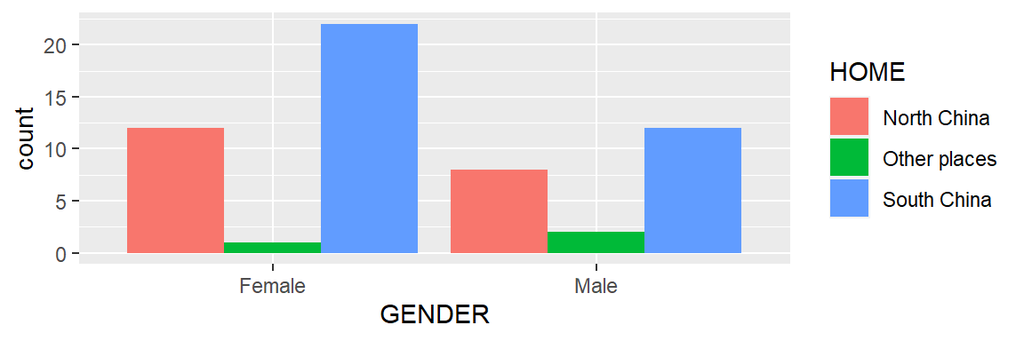

```r
ggplot(x) + geom_bar(aes(x = GENDER, fill = HOME), position = 'dodge')
```

### 6.2.3 Three-way tables

```r
table(x$GENDER, x$HOME, x$YEAR)
```

```
, ,  = 1998


         North China Other places South China
  Female           0            0           0
  Male             1            1           0

, ,  = 1999


         North China Other places South China
  Female           1            0           1
  Male             1            0           0

, ,  = 2000


         North China Other places South China
  Female           0            0           1
  Male             4            0           0

, ,  = 2001


         North China Other places South China
  Female           4            0           4
  Male             0            0           5

, ,  = 2002


         North China Other places South China
  Female           6            1          16
  Male             1            1           6

, ,  = 2022


         North China Other places South China
  Female           0            0           0
  Male             0            0           1
```

```r
HairEyeColor
```

```
, , Sex = Male

       Eye
Hair    Brown Blue Hazel Green
  Black    32   11    10     3
  Brown    53   50    25    15
  Red      10   10     7     7
  Blond     3   30     5     8

, , Sex = Female

       Eye
Hair    Brown Blue Hazel Green
  Black    36    9     5     2
  Brown    66   34    29    14
  Red      16    7     7     7
  Blond     4   64     5     8
```

Question: How do you display it in a report/publication?

| Gender |  | Male |  |  |  | Female |  |  |  |
| --- | --- | --- | --- | --- | --- | --- | --- | --- | --- |
|  |  | Eye |  |  |  |  |  |  |  |
|  |  | Brown | Blue | Hazel | Green | Brown | Blue | Hazel | Green |
| Hair | Black | 32 | 11 | 10 | 3 | 36 | 9 | 5 | 2 |
|  | Brown | 53 | 50 | 25 | 15 | 66 | 34 | 29 | 14 |
|  | Red | 10 | 10 | 7 | 7 | 16 | 7 | 7 | 7 |
|  | Blond | 3 | 30 | 5 | 8 | 4 | 64 | 5 | 8 |

Question: How do you display it in a long version?

|  | Hair | Eye | Sex | Freq |
| --- | --- | --- | --- | --- |
| 1 | Black | Brown | Male | 32 |
| 2 | Brown | Brown | Male | 53 |
| 3 | Red | Brown | Male | 10 |
| 4 | Blond | Brown | Male | 3 |
| 5 | Black | Blue | Male | 11 |
| 6 | Brown | Blue | Male | 50 |
| 7 | Red | Blue | Male | 10 |
| 8 | Blond | Blue | Male | 30 |
| 9 | Black | Hazel | Male | 10 |
| 10 | Brown | Hazel | Male | 25 |

[output cut: 22 more lines]

More-way table:

```r
Titanic
```

```
, , Age = Child, Survived = No

      Sex
Class  Male Female
  1st     0      0
  2nd     0      0
  3rd    35     17
  Crew    0      0

, , Age = Adult, Survived = No

      Sex
Class  Male Female
  1st   118      4
  2nd   154     13
  3rd   387     89
  Crew  670      3

, , Age = Child, Survived = Yes

      Sex
Class  Male Female
  1st     5      1
  2nd    11     13
  3rd    13     14
  Crew    0      0

, , Age = Adult, Survived = Yes

      Sex
Class  Male Female
  1st    57    140
  2nd    14     80
  3rd    75     76
  Crew  192     20
```

Question: How do you display it in a long version?

|  | Class | Sex | Age | Survived | Freq |
| --- | --- | --- | --- | --- | --- |
| 1 | 1st | Male | Child | No | 0 |
| 2 | 2nd | Male | Child | No | 0 |
| 3 | 3rd | Male | Child | No | 35 |
| 4 | Crew | Male | Child | No | 0 |
| 5 | 1st | Female | Child | No | 0 |
| 6 | 2nd | Female | Child | No | 0 |
| 7 | 3rd | Female | Child | No | 17 |
| 8 | Crew | Female | Child | No | 0 |
| 9 | 1st | Male | Adult | No | 118 |
| 10 | 2nd | Male | Adult | No | 154 |

[output cut: 22 more lines]

Visualization: bar plots and mosaic plot

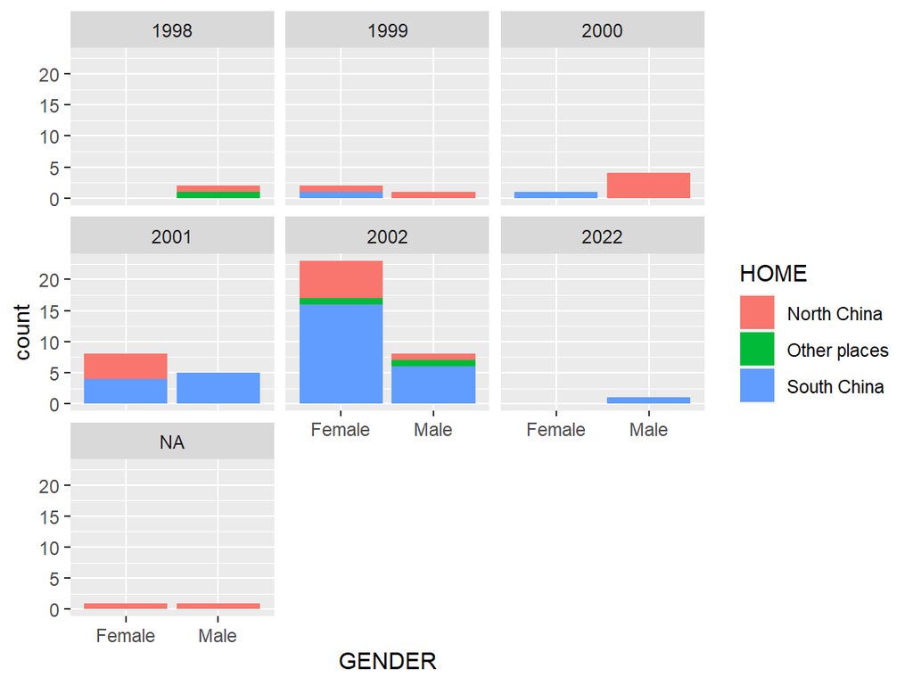

```r
ggplot(x) + geom_bar(aes(x = GENDER, fill = HOME)) +
  facet_wrap( ~ YEAR)
```

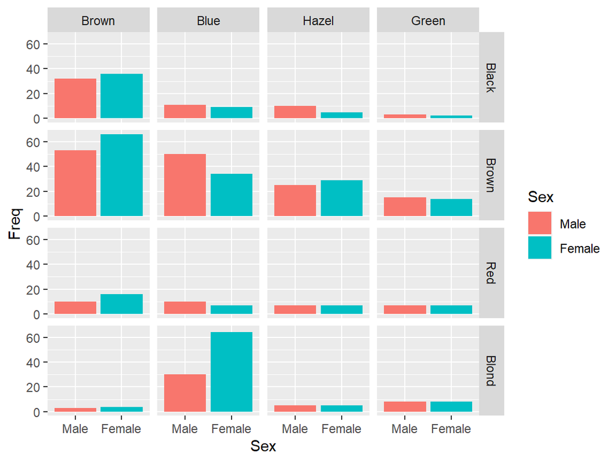

```r
ggplot(data.frame(HairEyeColor)) +
  geom_bar(aes(y = Freq, x = Sex, fill = Sex), stat = 'identity') +
  facet_grid(Hair ~ Eye)
```

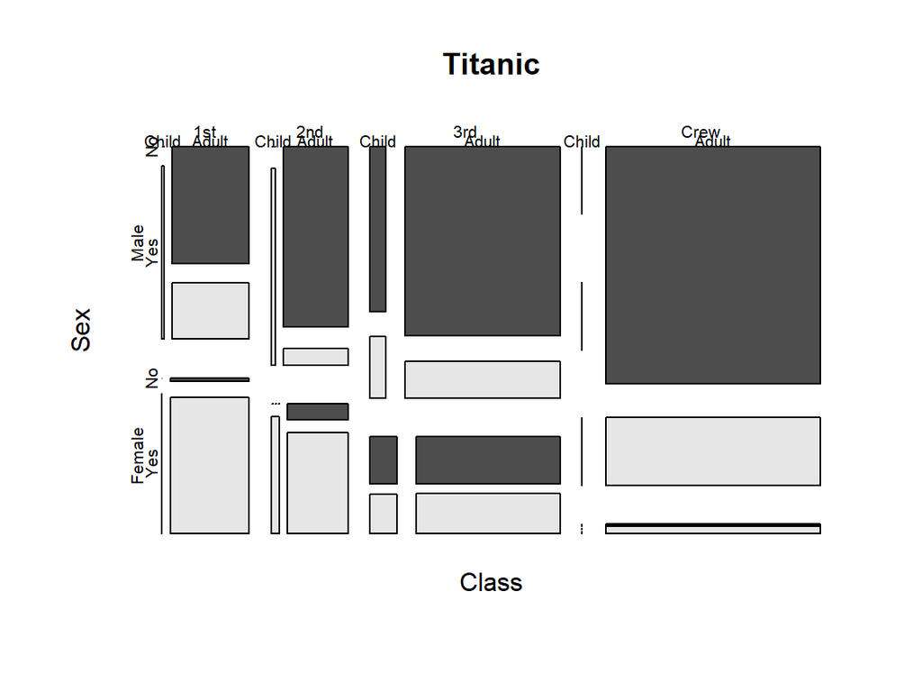

```r
mosaicplot(Titanic, color = TRUE)
```

## 6.3 Numerical data

### 6.3.1 Describe the center

*Mean*

- Arithmetic Mean: $\mu = \Sigma x_i / N$, $\bar x = \Sigma x_i / n$.
- Geometric Mean: $G=\sqrt[n] {\Pi x_i}$
- Harmonic Mean: $H = n/\Sigma \frac{1}{x_i}$

Example:

The daily temperatures for last week were $t_1 = 27, t_2 = 26, t_3 = 30, t_4 = 27, t_5 = 29, t_6 = 30, t_7 = 25 ^\circ$C. What was the mean temperature?

```r
(27+ 26 + 30 + 27 + 29 + 30 + 25) / 7
tc <- c(27, 26, 30, 27, 29, 30, 25)
sum(tc)/length(tc)
mean(tc)
```

**Median:**

Middle value of an ordered set. Also called $Q_2$ and $P_{50}$.

Examples:

- What is the median of the sepal length in the iris dataset?

```r
mean(sort(iris$Sepal.Length)[75:76])

median(iris$Sepal.Length)
```

- You wanted to know the surface water temperature of the Taihu Lake. You randomly selected four locations at 11:59 PM on 1/1/2021, and got the following temperatures: 3.0, 2.1, 3.0 and 24 $^\circ$C. Find the measures of the center with the mean and median.

```r
tc <- c(3.0, 2.1, 3.0, 24)
mean(tc)
median(tc)
```

- Mean: the best way to estimate a subject of a population
- Median: the safest.
- Both are insufficient and unsatisfactory because of the lack of the spread.

### 6.3.2 Describe the spread

**Generic Measure: Range**

$x_\text{max} - x_\text{min}$

Example: What is the range of the sepal length in the iris dataset?

```r
max(iris$Sepal.Length) - min(iris$Sepal.Length)
```

```
[1] 3.6
```

```r
range(iris$Sepal.Length)
```

```
[1] 4.3 7.9
```

**Paired with the mean: Standard deviation**

Variance: for a population, $\sigma^2 = \frac{\Sigma (x_i - \mu)^2}{N}$; for a sample, $s^2 = \frac{\Sigma (x_i - \bar x)^2}{n-1}$

Standard deviation: $\sigma$, $s$

Coefficient of variation: $c_v = \sigma / \mu$, $c_v = s / \bar x$

Example: what are the standard deviation, the variance, and coefficient of variation for the sepal length in the iris dataset?

```r
x <- iris$Sepal.Length
n <- length(x)
x_bar <- mean(x)
x_variance <- sum((x - x_bar) ^ 2) / (n - 1)
x_sd <- sqrt(x_variance)
x_cv <- x_sd/x_bar

# use the built-in functions:
var(x)
sd(x)
```

**Paired with the median: Quartiles/Percentiles**

The *p*-th percentile: the value $V_p$ such that *p*% of the sample points are less than or equal to $V_p$.

Three quartiles:$Q_1 = P_{25}$, $Q_2 = P_{50} = \mathrm {median}$, $Q_3 = P_{75}$.

Interquartile range (IQR): $\text{IQR} = Q_3 − Q_1 = P_{75} − P_{25}$

Example: Calculate $Q_1, Q_2, Q_3$, and IQR of the sepal length in the iris dataset.

```r
x <- iris$Sepal.Length
q1 <- sort(x)[round(150 * 0.25)]
q2 <- median(x)
q3 <- sort(x)[round(150 * 0.75)]
quantile(x, probs = c(0.25, 0.5, 0.75))
IQR(x)
fivenum(x)
summary(x)
```

### 6.3.3 Visualizing the center and the spread

**Frequency distribution table**

Example: Sepal length in iris

| Class | Frequency | Midpoint | Relative_frequency | Cumulative_frequency |
| --- | --- | --- | --- | --- |
| 4.1 - 4.5 | 5 | 4.3 | 0.033 | 0.033 |
| 4.6 - 5 | 27 | 4.8 | 0.180 | 0.213 |
| 5.1 - 5.5 | 27 | 5.3 | 0.180 | 0.393 |
| 5.6 - 6 | 30 | 5.8 | 0.200 | 0.593 |
| 6.1 - 6.5 | 31 | 6.3 | 0.207 | 0.800 |
| 6.6 - 7 | 18 | 6.8 | 0.120 | 0.920 |
| 7.1 - 7.5 | 6 | 7.3 | 0.040 | 0.960 |
| 7.6 - 8 | 6 | 7.8 | 0.040 | 1.000 |

Question: How to make this table?

```r
freq <- hist(iris$Sepal.Length, plot = FALSE)
dtf_freq <- data.frame(Class = paste0(freq$breaks[-length(freq$breaks)] + 0.1, ' - ', freq$breaks[-1]),
                       Frequency = freq$counts,
                       Midpoint = freq$mids + 0.05)
dtf_freq$Relative_frequency <- round(dtf_freq$Frequency / length(iris$Sepal.Length), 3)
dtf_freq$Cumulative_frequency <- cumsum(dtf_freq$Relative_frequency)
dtf_freq
```

**Histogram:**

display numerical data by indicating the number of data points that lie within a range of values. These ranges of values are called classes or bins.

Example: Histogram for the sepal length of the iris dataset.

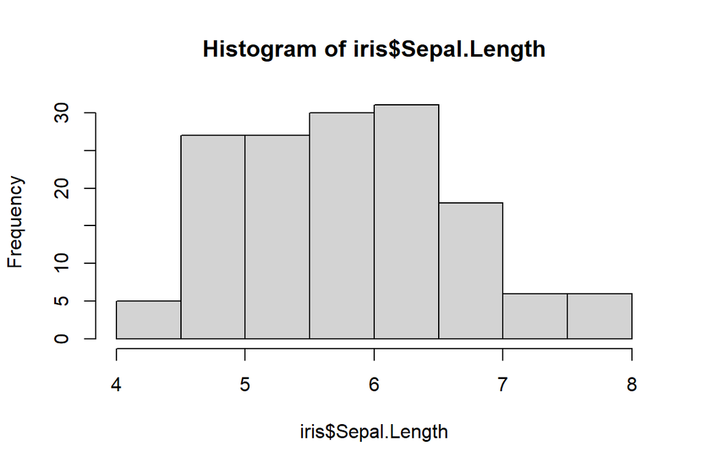

```r
hist(iris$Sepal.Length)
```

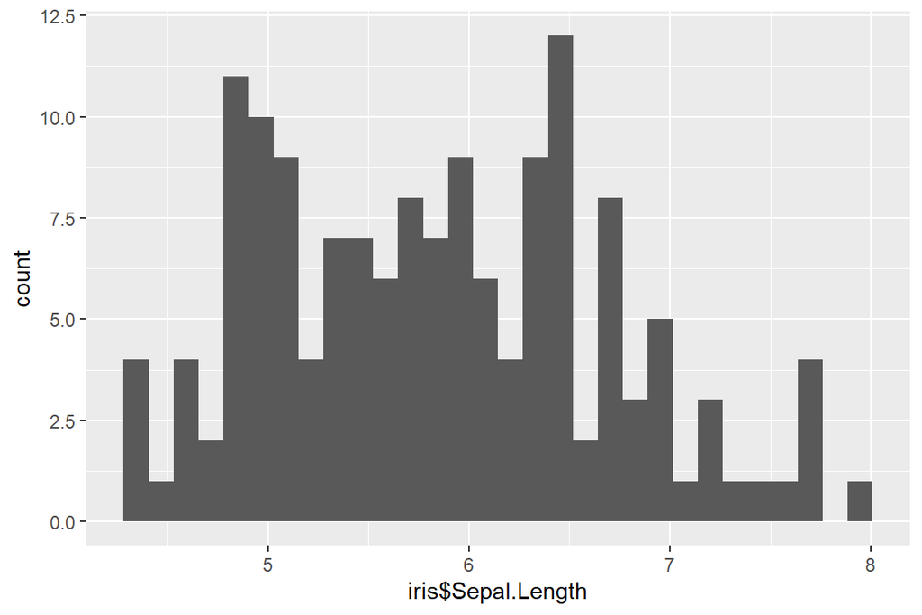

```r
ggplot(iris) + geom_histogram(aes(iris$Sepal.Length))
```

*Question*: How many bins should we use?

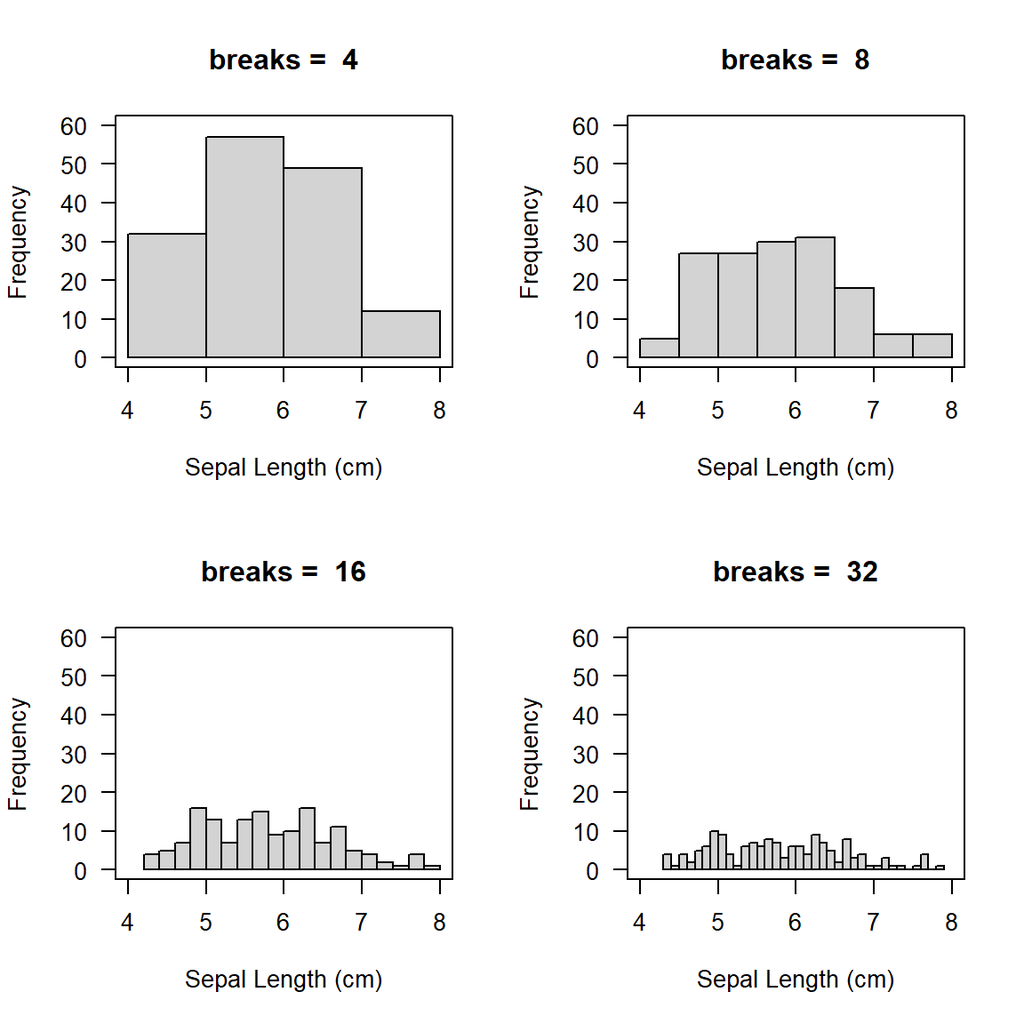

Different bins for histograms

```r
par(mfrow= c(2, 2), las = 1)
for (bins in c(4, 8, 16, 32)){
  hist(iris$Sepal.Length,
       breaks = bins,
       main = paste("breaks = ", bins),
       xlim = c(4, 8), ylim = c(0, 60),
       xlab = "Sepal Length (cm)")
  box()
}
```

Sturges’ Rule:

$$n_\text{class} = 1 + \frac{\log_{10}N}{\log_{10}2} = 1 + \log_2 N$$

```r
1 + log10(nrow(iris)) / log10(2)
```

```
[1] 8.228819
```

```r
1 + log2(nrow(iris))
```

```
[1] 8.228819
```

```r
nclass.Sturges(iris$Sepal.Length)
```

```
[1] 9
```

```r
nclass.scott(iris$Sepal.Length)
```

```
[1] 7
```

```r
nclass.FD(iris$Sepal.Length)
```

```
[1] 8
```

Question: The y-scales might be different with different bins. Why?

**Density curve:**

Example: Density curve for the sepal length of the iris dataset.

```r
hist(iris$Sepal.Length, freq = FALSE)
lines(density(iris$Sepal.Length), col = "blue")
```

[output not shown]

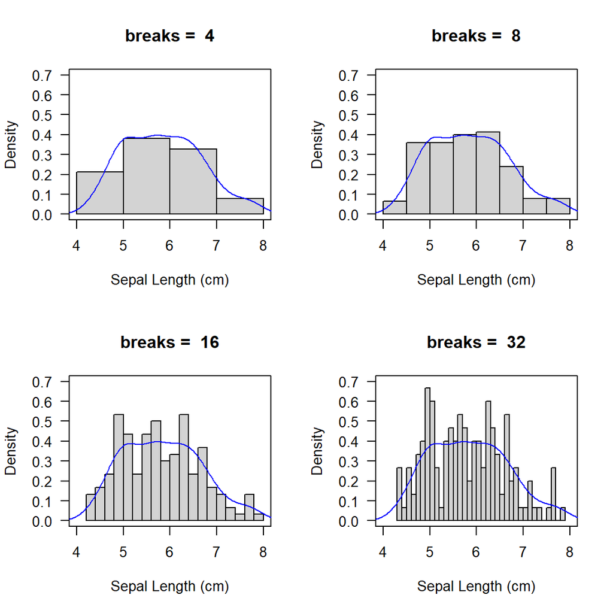

Histogram of the density

```r
par(mfrow= c(2, 2), las = 1)
#| code-fold: true
for (bins in c(4, 8, 16, 32)){
  hist(iris$Sepal.Length,
       freq = FALSE,
       breaks = bins,
       main = paste("breaks = ", bins),
       xlim = c(4, 8),
       ylim = c(0, 0.7),
       xlab = "Sepal Length (cm)")
  box()
  lines(density(iris$Sepal.Length), col = "blue")
}
```

`Frequency = Density * bin-width * total frequency`

**Box plot (box-and-whisker plot):**

Show groups of numerical data through their quartiles, with lines extending from the boxes (whiskers) indicating variability outside the upper and lower quartiles.

Example: box plot for the sepal length in the iris dataset.

[figure not shown]

```r
boxplot(iris$Sepal.Length,
        horizontal = TRUE,
        xlab = 'Sepal length (cm)')
points(mean(iris$Sepal.Length), 1, col = "red", pch = 16)

ggplot(iris, aes(y = Sepal.Length)) +
  geom_boxplot() +
  geom_jitter(aes(x = 0), color = 'lightblue') +
  stat_summary(aes(x = 0), fun = mean, color="red") +
  labs(x = '', y = 'Sepal Length (cm)') +
  theme(axis.ticks.y = element_blank(),
        axis.text.y = element_blank()) +
  coord_flip()
```

Question: How do you draw a box plot for the sepal length for each species?

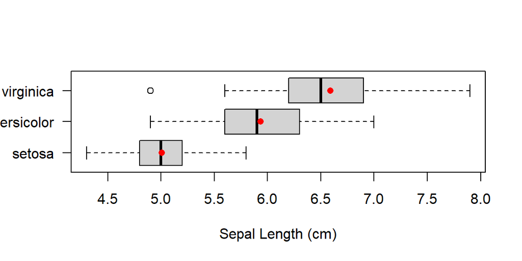

```r
boxplot(iris$Sepal.Length ~ iris$Species,
        horizontal = TRUE, las = 1,
        xlab = 'Sepal Length (cm)', ylab = '')
sepal_length_mean <- tapply(iris$Sepal.Length, iris$Species, mean)
points(sepal_length_mean, 1:3, col = "red", pch = 16)
```

```r
tapply(iris$Sepal.Length, iris$Species, summary)
```

```
$setosa
   Min. 1st Qu.  Median    Mean 3rd Qu.    Max.
  4.300   4.800   5.000   5.006   5.200   5.800

$versicolor
   Min. 1st Qu.  Median    Mean 3rd Qu.    Max.
  4.900   5.600   5.900   5.936   6.300   7.000

$virginica
   Min. 1st Qu.  Median    Mean 3rd Qu.    Max.
  4.900   6.225   6.500   6.588   6.900   7.900
```

**Violin plot:**

a combination of a box plot and a density plot to show the distribution shape of the data

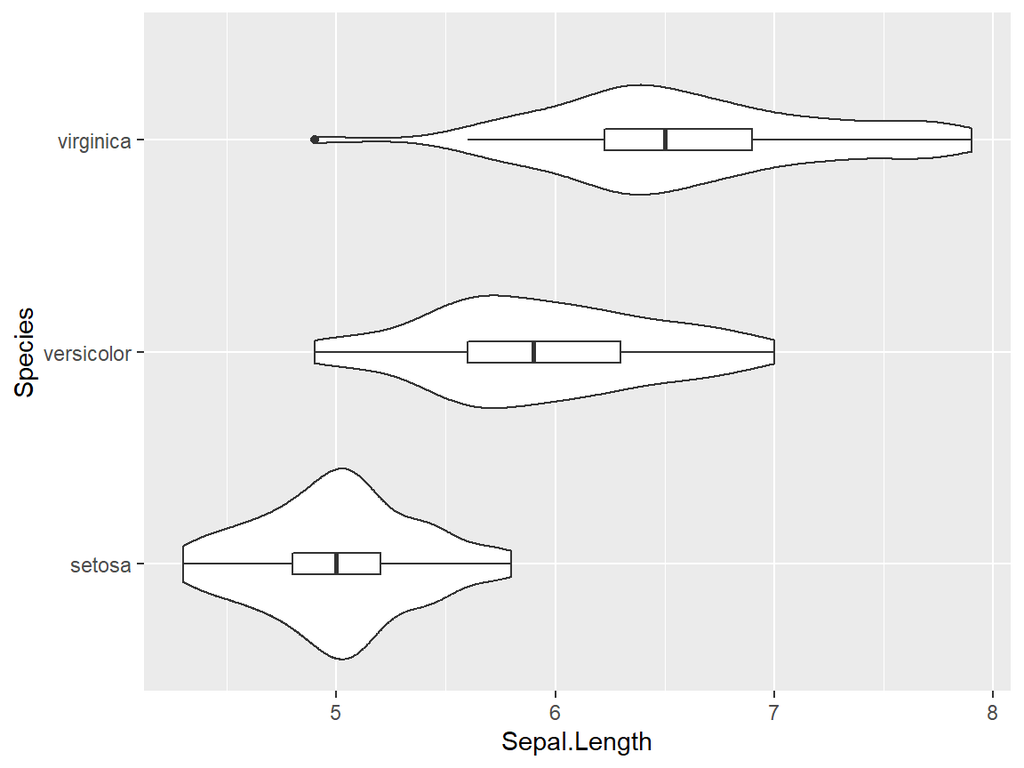

```r
ggplot(iris, aes(x = Species, y = Sepal.Length)) +
  geom_violin() +
  geom_boxplot(width = 0.1) +
  coord_flip()
```

### 6.3.4 Describe the shape

**Skewness:**

Central symmetry - No skew - Left skew - Right skew

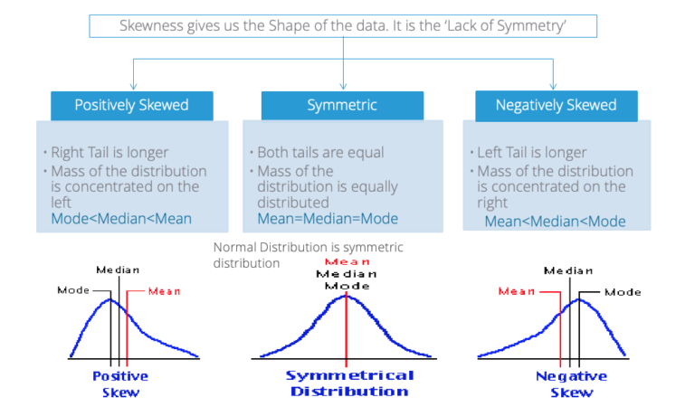

Example: Calculate the skewness of the sepal length in the iris dataset.

```r
library(e1071)
hist(iris$Sepal.Length)
skewness(iris$Sepal.Length)
hist(mtcars$mpg)
skewness(mtcars$mpg)
```

- skewness < -1: much left/negative skew.
- -1 < skewness < -0.5: moderately left/negative skew.
- -0.5 < skewness < 0.5: approximately symmetric.
- 0.5 < skewness < 1: moderately right/positive skew.
- 1 < skewness: much right/positive skew.

**Kurtosis:**

Peakedness - Leptokurtic distributions: tall and slender. - Platykurtic distributions: broad and flat.

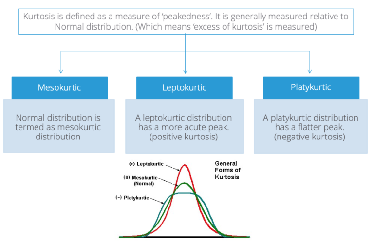

```r
kurtosis(iris$Sepal.Length)
```

- kurtosis < 0: platykurtic.
- kurtosis = 0: mesokurtic.–> normal distribution (-7 to +7, Bryne (2010)).
- kurtosis > 0: leptokurtic.

## 6.4 Readings

- Manga Guide to Statistics - Chapter 2 and 3